# USA Covid Data

Amritha Girish

15/08/2021

To load the data set:

```r
data=read.csv("USA Covid Data.csv")
```

To display the first 6 rows of the data set

```r
head(data)
```

```
##        State Total.Cases Total.Deaths Total.Recovered Active.Cases
## 1    Alabama      589110        11536              NA           NA
## 2     Alaska       72988          382           67322         5284
## 3    Arizona      931387        18252          879184        33951
## 4   Arkansas      389280         6199          364054        19027
## 5 California     3983692        64543         2105689      1813460
## 6   Colorado      577285         7213          509648        60424
##   Total.Cases.1.mil.population Death.1.mil.population Total.Tests
## 1                       120148                   2353     2906242
## 2                        99772                    522     2509643
## 3                       127960                   2508     5287252
## 4                       128994                   2054     4082199
## 5                       100822                   1633    74176215
## 6                       100245                   1253     3287765
##   Tests.1.mil.population Population
## 1                 592725    4903185
## 2                3430606     731545
## 3                 726399    7278717
## 4                1352705    3017804
## 5                1877298   39512223
## 6                 570918    5758736
```

To show the number of specified rows i.e for n=8, it will display the first 8 rows

```r
head(data, n=8)
```

```
##         State Total.Cases Total.Deaths Total.Recovered Active.Cases
## 1     Alabama      589110        11536              NA           NA
## 2      Alaska       72988          382           67322         5284
## 3     Arizona      931387        18252          879184        33951
## 4    Arkansas      389280         6199          364054        19027
## 5  California     3983692        64543         2105689      1813460
## 6    Colorado      577285         7213          509648        60424
## 7 Connecticut      355580         8293          341015         6272
## 8    Delaware      111681         1833          108120         1728
##   Total.Cases.1.mil.population Death.1.mil.population Total.Tests
## 1                       120148                   2353     2906242
## 2                        99772                    522     2509643
## 3                       127960                   2508     5287252
## 4                       128994                   2054     4082199
## 5                       100822                   1633    74176215
## 6                       100245                   1253     3287765
## 7                        99734                   2326     9944525
## 8                       114690                   1882      754246
##   Tests.1.mil.population Population
## 1                 592725    4903185
## 2                3430606     731545
## 3                 726399    7278717
## 4                1352705    3017804
## 5                1877298   39512223
## 6                 570918    5758736
## 7                2789264    3565287
## 8                 774568     973764
```

To display the last Rows of your data

```r
tail(data)
```

```
##            State Total.Cases Total.Deaths Total.Recovered Active.Cases
## 45       Vermont       25038          260           24234          544
## 46      Virginia      699342        11536           58179       629627
## 47    Washington      477723         6172          231097       240454
## 48 West Virginia      167681         2949          162252         2480
## 49     Wisconsin      689284         8295              NA           NA
## 50       Wyoming       65467          776           63712          979
##    Total.Cases.1.mil.population Death.1.mil.population Total.Tests
## 45                        40126                    417     1780906
## 46                        81933                   1352    10707391
## 47                        62735                    811     8844896
## 48                        93564                   1646     3133703
## 49                       118384                   1425     3660315
## 50                       113116                   1341      822614
##    Tests.1.mil.population Population
## 45                2854066     623989
## 46                1254451    8535519
## 47                1161526    7614893
## 48                1748575    1792147
## 49                 628657    5822434
## 50                1421341     578759
```

To view the previously Loaded named object we use ls() command

```r
ls()
```

```
## [1] "data"
```

for examining the data structure of an object str() command can be used

```r
str(data)
```

```
## 'data.frame':    50 obs. of  10 variables:
##  $ State                       : chr  "Alabama" "Alaska" "Arizona" "Arkansas" ...
##  $ Total.Cases                 : int  589110 72988 931387 389280 3983692 577285 355580 111681 2636066 1185571 ...
##  $ Total.Deaths                : int  11536 382 18252 6199 64543 7213 8293 1833 39079 21698 ...
##  $ Total.Recovered             : num  NA 67322 879184 364054 2105689 ...
##  $ Active.Cases                : num  NA 5284 33951 19027 1813460 ...
##  $ Total.Cases.1.mil.population: int  120148 99772 127960 128994 100822 100245 99734 114690 122735 111663 ...
##  $ Death.1.mil.population      : num  2353 522 2508 2054 1633 ...
##  $ Total.Tests                 : int  2906242 2509643 5287252 4082199 74176215 3287765 9944525 754246 33225562 12506402 ...
##  $ Tests.1.mil.population      : num  592725 3430606 726399 1352705 1877298 ...
##  $ Population                  : int  4903185 731545 7278717 3017804 39512223 5758736 3565287 973764 21477737 10617423 ...
```

to pick out item from third row and third columns:

```r
data[3,3]
```

```
## [1] 18252
```

to display the values of third row corresponding to columns from one to four:

```r
data[3,1:4]
```

```
##     State Total.Cases Total.Deaths Total.Recovered
## 3 Arizona      931387        18252          879184
```

for displaying all the rows by leaving out the first value and selecting just the first column:

```r
data[,1]
```

```
##  [1] "Alabama"        "Alaska"         "Arizona"        "Arkansas"
##  [5] "California"     "Colorado"       "Connecticut"    "Delaware"
##  [9] "Florida"        "Georgia"        "Hawaii"         "Idaho"
## [13] "Illinois"       "Indiana"        "Iowa"           "Kansas"
## [17] "Kentucky"       "Louisiana"      "Maine"          "Maryland"
## [21] "Massachusetts"  "Michigan"       "Minnesota"      "Mississippi"
## [25] "Missouri"       "Montana"        "Nebraska"       "Nevada"
## [29] "New Hampshire"  "New Jersey"     "New Mexico"     "New York"
## [33] "North Carolina" "North Dakota"   "Ohio"           "Oklahoma"
## [37] "Oregon"         "Pennsylvania"   "Rhode Island"   "South Carolina"
## [41] "South Dakota"   "Tennessee"      "Texas"          "Utah"
## [45] "Vermont"        "Virginia"       "Washington"     "West Virginia"
## [49] "Wisconsin"      "Wyoming"
```

specifying rows and displaying values for all columns:

```r
data[c(1,3,5,7),]
```

```
##         State Total.Cases Total.Deaths Total.Recovered Active.Cases
## 1     Alabama      589110        11536              NA           NA
## 3     Arizona      931387        18252          879184        33951
## 5  California     3983692        64543         2105689      1813460
## 7 Connecticut      355580         8293          341015         6272
##   Total.Cases.1.mil.population Death.1.mil.population Total.Tests
## 1                       120148                   2353     2906242
## 3                       127960                   2508     5287252
## 5                       100822                   1633    74176215
## 7                        99734                   2326     9944525
##   Tests.1.mil.population Population
## 1                 592725    4903185
## 3                 726399    7278717
## 5                1877298   39512223
## 7                2789264    3565287
```

specifying several rows and using -4 to display all the columns except the fourth:

```r
data[c(1,3,5,7),-4]
```

```
##         State Total.Cases Total.Deaths Active.Cases
## 1     Alabama      589110        11536           NA
## 3     Arizona      931387        18252        33951
## 5  California     3983692        64543      1813460
## 7 Connecticut      355580         8293         6272
##   Total.Cases.1.mil.population Death.1.mil.population Total.Tests
## 1                       120148                   2353     2906242
## 3                       127960                   2508     5287252
## 5                       100822                   1633    74176215
## 7                        99734                   2326     9944525
##   Tests.1.mil.population Population
## 1                 592725    4903185
## 3                 726399    7278717
## 5                1877298   39512223
## 7                2789264    3565287
```

Since the columns are named we can use the name instead of values:

```r
data[c(1,3,5,7),'Population']
```

```
## [1]  4903185  7278717 39512223  3565287
```

Giving a single value in the square brackets, this will display the values in third column along with all the rows:

```r
data[3]
```

```
##    Total.Deaths
## 1         11536
## 2           382
## 3         18252
## 4          6199
## 5         64543
## 6          7213
## 7          8293
## 8          1833
## 9         39079
## 10        21698
## 11          537
## 12         2203
## 13        25930
## 14        14012
```

[output cut: 36 more lines]

If you append $ and then the name of the required column you will view that column data:

```r
data$Total.Deaths
```

```
##  [1] 11536   382 18252  6199 64543  7213  8293  1833 39079 21698   537  2203
## [13] 25930 14012  6183  5266  7348 11026   900  9829 18084 21188  7767  7556
## [25] 10317  1708  2280  5918  1387 26606  4414 54259 13670  1539 20492  7485
## [37]  2863 27957  2740  9915  2043 12758 53524  2466   260 11536  6172  2949
## [49]  8295   776
```

You can also use square brackets to select out parts of the item:

```r
#this will give the first four values of the column
data$Total.Deaths[1:4]
```

```
## [1] 11536   382 18252  6199
```

The summary command gives us some simple statistics about the numeric data:

```r
summary(data)
```

```
##     State            Total.Cases       Total.Deaths   Total.Recovered
##  Length:50          Min.   :  25038   Min.   :  260   Min.   :   9475
##  Class :character   1st Qu.: 203887   1st Qu.: 2534   1st Qu.: 119796
##  Mode  :character   Median : 481919   Median : 7520   Median : 368095
##                     Mean   : 700174   Mean   :12224   Mean   : 630362
##                     3rd Qu.: 868838   3rd Qu.:13926   3rd Qu.: 875674
##                     Max.   :3983692   Max.   :64543   Max.   :2958075
##                                                       NA's   :7
##   Active.Cases     Total.Cases.1.mil.population Death.1.mil.population
##  Min.   :    434   Min.   : 30530               Min.   : 379
##  1st Qu.:   5778   1st Qu.: 99890               1st Qu.:1344
##  Median :  23131   Median :112068               Median :1833
##  Mean   : 108708   Mean   :106079               Mean   :1726
##  3rd Qu.:  78524   3rd Qu.:118779               3rd Qu.:2099
##  Max.   :1813460   Max.   :146575               Max.   :2995
##  NA's   :7
##   Total.Tests       Tests.1.mil.population   Population
##  Min.   :  453933   Min.   : 519225        Min.   :  578759
##  1st Qu.: 2855635   1st Qu.:1164266        1st Qu.: 1827712
##  Median : 5327246   Median :1394970        Median : 4558234
##  Mean   :10464778   Mean   :1570324        Mean   : 6550675
##  3rd Qu.:11305402   3rd Qu.:1818358        3rd Qu.: 7530849
##  Max.   :74176215   Max.   :4363921        Max.   :39512223
##
```

To see the summary of a particular column:

```r
summary(data$Total.Cases.1.mil.population)
```

```
##    Min. 1st Qu.  Median    Mean 3rd Qu.    Max.
##   30530   99890  112068  106079  118779  146575
```

To find the mean of a particular column:

```r
mean(data$Total.Deaths)
```

```
## [1] 12223.72
```

To find the median of a particular column:

```r
median(data$Total.Deaths)
```

```
## [1] 7520.5
```

To find variance of a column:

```r
var(data$Total.Deaths)
```

```
## [1] 206098038
```

To find standard deviation:

```r
sd(data$Total.Deaths)
```

```
## [1] 14356.11
```

To calculate the Standard deviation but after revoming the NA items with an additional instruction

```r
sd(data$Total.Deaths,na.rm=TRUE)
```

```
## [1] 14356.11
```

```r
quantile(data$Total.Deaths)
```

```
##      0%     25%     50%     75%    100%
##   260.0  2534.5  7520.5 13926.5 64543.0
```

To find 20% quantile:

```r
quantile(data$Total.Cases,0.2)
```

```
##      20%
## 148875.2
```

To find 20%,50% and 80% quantile:

```r
quantile(data$Total.Cases,c(0.2,0.5,0.8))
```

```
##       20%       50%       80%
##  148875.2  481919.0 1017116.6
```

To Returns five number summary (minimum, lower-hinge, median, upper-hinge, maximum) for the input data.

```r
fivenum(data$Total.Cases)
```

```
## [1]   25038  201352  481919  900418 3983692
```

The most basic command that enables the viewing of columns or row is name():

```r
names(data)
```

```
##  [1] "State"                        "Total.Cases"
##  [3] "Total.Deaths"                 "Total.Recovered"
##  [5] "Active.Cases"                 "Total.Cases.1.mil.population"
##  [7] "Death.1.mil.population"       "Total.Tests"
##  [9] "Tests.1.mil.population"       "Population"
```

For displaying the row names:

```r
row.names(data)
```

```
##  [1] "1"  "2"  "3"  "4"  "5"  "6"  "7"  "8"  "9"  "10" "11" "12" "13" "14" "15"
## [16] "16" "17" "18" "19" "20" "21" "22" "23" "24" "25" "26" "27" "28" "29" "30"
## [31] "31" "32" "33" "34" "35" "36" "37" "38" "39" "40" "41" "42" "43" "44" "45"
## [46] "46" "47" "48" "49" "50"
```

For displaying the column names:

```r
colnames(data)
```

```
##  [1] "State"                        "Total.Cases"
##  [3] "Total.Deaths"                 "Total.Recovered"
##  [5] "Active.Cases"                 "Total.Cases.1.mil.population"
##  [7] "Death.1.mil.population"       "Total.Tests"
##  [9] "Tests.1.mil.population"       "Population"
```

To display both row names and the column names at the same time we can use the command dimnames()

```r
dimnames(data)
```

```
## [[1]]
##  [1] "1"  "2"  "3"  "4"  "5"  "6"  "7"  "8"  "9"  "10" "11" "12" "13" "14" "15"
## [16] "16" "17" "18" "19" "20" "21" "22" "23" "24" "25" "26" "27" "28" "29" "30"
## [31] "31" "32" "33" "34" "35" "36" "37" "38" "39" "40" "41" "42" "43" "44" "45"
## [46] "46" "47" "48" "49" "50"
##
## [[2]]
##  [1] "State"                        "Total.Cases"
##  [3] "Total.Deaths"                 "Total.Recovered"
##  [5] "Active.Cases"                 "Total.Cases.1.mil.population"
##  [7] "Death.1.mil.population"       "Total.Tests"
##  [9] "Tests.1.mil.population"       "Population"
```

Omitting NA items:

```r
length(na.omit(data$Total.Recovered))
```

```
## [1] 43
```

Interpreting the type of object using the class() command:

```r
class(data)
```

```
## [1] "data.frame"
```

```r
class(data$Total.Deaths)
```

```
## [1] "integer"
```

```r
class(dimnames(data))
```

```
## [1] "list"
```

Rotating the data frames, rows become columns and vice versa.

```r
t(data)
```

```
##                              [,1]       [,2]       [,3]       [,4]
## State                        "Alabama"  "Alaska"   "Arizona"  "Arkansas"
## Total.Cases                  " 589110"  "  72988"  " 931387"  " 389280"
## Total.Deaths                 "11536"    "  382"    "18252"    " 6199"
## Total.Recovered              NA         "  67322"  " 879184"  " 364054"
## Active.Cases                 NA         "   5284"  "  33951"  "  19027"
## Total.Cases.1.mil.population "120148"   " 99772"   "127960"   "128994"
## Death.1.mil.population       "2353"     " 522"     "2508"     "2054"
## Total.Tests                  " 2906242" " 2509643" " 5287252" " 4082199"
## Tests.1.mil.population       " 592725"  "3430606"  " 726399"  "1352705"
## Population                   " 4903185" "  731545" " 7278717" " 3017804"
##                              [,5]         [,6]       [,7]          [,8]
## State                        "California" "Colorado" "Connecticut" "Delaware"
## Total.Cases                  "3983692"    " 577285"  " 355580"     " 111681"
## Total.Deaths                 "64543"      " 7213"    " 8293"       " 1833"
## Total.Recovered              "2105689"    " 509648"  " 341015"     " 108120"
## Active.Cases                 "1813460"    "  60424"  "   6272"     "   1728"
## Total.Cases.1.mil.population "100822"     "100245"   " 99734"      "114690"
## Death.1.mil.population       "1633"       "1253"     "2326"        "1882"
## Total.Tests                  "74176215"   " 3287765" " 9944525"    "  754246"
## Tests.1.mil.population       "1877298"    " 570918"  "2789264"     " 774568"
## Population                   "39512223"   " 5758736" " 3565287"    "  973764"
##                              [,9]       [,10]      [,11]      [,12]
## State                        "Florida"  "Georgia"  "Hawaii"   "Idaho"
## Total.Cases                  "2636066"  "1185571"  "  43227"  " 201352"
## Total.Deaths                 "39079"    "21698"    "  537"    " 2203"
## Total.Recovered              "2289018"  "1089121"  NA         " 116853"
## Active.Cases                 " 307969"  "  74752"  NA         "  82296"
## Total.Cases.1.mil.population "122735"   "111663"   " 30530"   "112672"
## Death.1.mil.population       "1820"     "2044"     " 379"     "1233"
## Total.Tests                  "33225562" "12506402" " 1865038" " 1459164"
## Tests.1.mil.population       "1546977"  "1177913"  "1317236"  " 816514"
## Population                   "21477737" "10617423" " 1415872" " 1787065"
##                              [,13]      [,14]      [,15]      [,16]
## State                        "Illinois" "Indiana"  "Iowa"     "Kansas"
## Total.Cases                  "1425219"  " 774097"  " 410166"  " 334636"
## Total.Deaths                 "25930"    "14012"    " 6183"    " 5266"
## Total.Recovered              "1365687"  " 736788"  " 368095"  " 312410"
## Active.Cases                 "  33602"  "  23297"  "  35888"  "  16960"
## Total.Cases.1.mil.population "112472"   "114984"   "130002"   "114864"
```

[output cut: 99 more lines]

```
## Death.1.mil.population       " 417"     "1352"     " 811"       "1646"
## Total.Tests                  " 1780906" "10707391" " 8844896"   " 3133703"
## Tests.1.mil.population       "2854066"  "1254451"  "1161526"    "1748575"
## Population                   "  623989" " 8535519" " 7614893"   " 1792147"
##                              [,49]       [,50]
## State                        "Wisconsin" "Wyoming"
## Total.Cases                  " 689284"   "  65467"
## Total.Deaths                 " 8295"     "  776"
## Total.Recovered              NA          "  63712"
## Active.Cases                 NA          "    979"
## Total.Cases.1.mil.population "118384"    "113116"
## Death.1.mil.population       "1425"      "1341"
## Total.Tests                  " 3660315"  "  822614"
## Tests.1.mil.population       " 628657"   "1421341"
## Population                   " 5822434"  "  578759"
```

The cbind() and rbind() commands assemble a matrix/data frames, by columns or rows, from several other object

```r
head(rbind(data))
```

```
##        State Total.Cases Total.Deaths Total.Recovered Active.Cases
## 1    Alabama      589110        11536              NA           NA
## 2     Alaska       72988          382           67322         5284
## 3    Arizona      931387        18252          879184        33951
## 4   Arkansas      389280         6199          364054        19027
## 5 California     3983692        64543         2105689      1813460
## 6   Colorado      577285         7213          509648        60424
##   Total.Cases.1.mil.population Death.1.mil.population Total.Tests
## 1                       120148                   2353     2906242
## 2                        99772                    522     2509643
## 3                       127960                   2508     5287252
## 4                       128994                   2054     4082199
## 5                       100822                   1633    74176215
## 6                       100245                   1253     3287765
##   Tests.1.mil.population Population
## 1                 592725    4903185
## 2                3430606     731545
## 3                 726399    7278717
## 4                1352705    3017804
## 5                1877298   39512223
## 6                 570918    5758736
```

```r
head(cbind(data))
```

```
##        State Total.Cases Total.Deaths Total.Recovered Active.Cases
## 1    Alabama      589110        11536              NA           NA
## 2     Alaska       72988          382           67322         5284
## 3    Arizona      931387        18252          879184        33951
## 4   Arkansas      389280         6199          364054        19027
## 5 California     3983692        64543         2105689      1813460
## 6   Colorado      577285         7213          509648        60424
##   Total.Cases.1.mil.population Death.1.mil.population Total.Tests
## 1                       120148                   2353     2906242
## 2                        99772                    522     2509643
## 3                       127960                   2508     5287252
## 4                       128994                   2054     4082199
## 5                       100822                   1633    74176215
## 6                       100245                   1253     3287765
##   Tests.1.mil.population Population
## 1                 592725    4903185
## 2                3430606     731545
## 3                 726399    7278717
## 4                1352705    3017804
## 5                1877298   39512223
## 6                 570918    5758736
```

Selecting and displaying parts of contingency table:

```r
data.tab=with(data,table(Total.Cases,Active.Cases))
data.tab
```

```
##            Active.Cases
## Total.Cases 434 448 544 738 979 1341 1348 1728 2480 4059 5284 6272 9999 13622
##     25038     0   0   1   0   0    0    0    0    0    0    0    0    0     0
##     43227     0   0   0   0   0    0    0    0    0    0    0    0    0     0
##     65467     0   0   0   0   1    0    0    0    0    0    0    0    0     0
##     70463     0   0   0   0   0    0    0    0    0    0    0    0    0     0
##     72988     0   0   0   0   0    0    0    0    0    0    1    0    0     0
##     100986    0   0   0   1   0    0    0    0    0    0    0    0    0     0
##     111681    0   0   0   0   0    0    0    1    0    0    0    0    0     0
##     111699    0   1   0   0   0    0    0    0    0    0    0    0    0     0
##     116634    0   0   0   0   0    1    0    0    0    0    0    0    0     0
##     125216    1   0   0   0   0    0    0    0    0    0    0    0    0     0
##     154790    0   0   0   0   0    0    0    0    0    0    0    0    0     0
##     167681    0   0   0   0   0    0    0    0    1    0    0    0    0     0
##     201352    0   0   0   0   0    0    0    0    0    0    0    0    0     0
```

[output cut: 193 more lines]

Now to display only 3 rows of the contingency table:

```r
data.tab[1:3,]
```

```
##            Active.Cases
## Total.Cases 434 448 544 738 979 1341 1348 1728 2480 4059 5284 6272 9999 13622
##       25038   0   0   1   0   0    0    0    0    0    0    0    0    0     0
##       43227   0   0   0   0   0    0    0    0    0    0    0    0    0     0
##       65467   0   0   0   0   1    0    0    0    0    0    0    0    0     0
##            Active.Cases
## Total.Cases 14283 14861 15460 16960 18108 19027 22739 23131 23297 23381 30305
##       25038     0     0     0     0     0     0     0     0     0     0     0
##       43227     0     0     0     0     0     0     0     0     0     0     0
##       65467     0     0     0     0     0     0     0     0     0     0     0
##            Active.Cases
## Total.Cases 30324 31112 33602 33951 35888 60424 74752 82296 86672 94692 117755
##       25038     0     0     0     0     0     0     0     0     0     0      0
##       43227     0     0     0     0     0     0     0     0     0     0      0
##       65467     0     0     0     0     0     0     0     0     0     0      0
##            Active.Cases
## Total.Cases 139440 142575 240454 307969 448616 629627 1813460
##       25038      0      0      0      0      0      0       0
##       43227      0      0      0      0      0      0       0
##       65467      0      0      0      0      0      0       0
```

Examine the table object using str() command:

```r
str(data.tab)
```

```
##  'table' int [1:50, 1:43] 0 0 0 0 0 0 0 0 0 1 ...
##  - attr(*, "dimnames")=List of 2
##   ..$ Total.Cases : chr [1:50] "25038" "43227" "65467" "70463" ...
##   ..$ Active.Cases: chr [1:43] "434" "448" "544" "738" ...
```

To determine the number of items in an object use length() command:

```r
length(data)
```

```
## [1] 10
```

The max() and min() commands display the largest and smallest values in a numeric object.

```r
max(data$Total.Cases)
```

```
## [1] 3983692
```

```r
row.names(data)[which(data$Total.Cases==3983692)]
```

```
## [1] "5"
```

```r
#California has the highest reported covid cases
```

```r
min(data$Total.Cases)
```

```
## [1] 25038
```

```r
row.names(data)[which(data$Total.Cases==25038)]
```

```
## [1] "45"
```

```r
#Vermont has the lowest reported covid cases
```

```r
max(data$Total.Deaths)
```

```
## [1] 64543
```

```r
row.names(data)[which(data$Total.Deaths==64543)]
```

```
## [1] "5"
```

```r
#california has highest deaths reported.
```

```r
min(data$Total.Deaths)
```

```
## [1] 260
```

```r
row.names(data)[which(data$Total.Deaths==260)]
```

```
## [1] "45"
```

```r
#Vermont has the lowest reported deaths.
```

We can sort the values in ascending order using command sort():

```r
head(sort(data$Total.Recovered))
```

```
## [1]  9475 11097 24234 58179 63712 67322
```

Converting an object into a table:

```r
d.tab=as.table(as.matrix(data))
d.tab
```

```
##    State          Total.Cases Total.Deaths Total.Recovered Active.Cases
## A  Alabama         589110     11536
## B  Alaska           72988       382          67322            5284
## C  Arizona         931387     18252         879184           33951
## D  Arkansas        389280      6199         364054           19027
## E  California     3983692     64543        2105689         1813460
## F  Colorado        577285      7213         509648           60424
## G  Connecticut     355580      8293         341015            6272
## H  Delaware        111681      1833         108120            1728
## I  Florida        2636066     39079        2289018          307969
## J  Georgia        1185571     21698        1089121           74752
## K  Hawaii           43227       537
## L  Idaho           201352      2203         116853           82296
## M  Illinois       1425219     25930        1365687           33602
## N  Indiana         774097     14012         736788           23297
## O  Iowa            410166      6183         368095           35888
## P  Kansas          334636      5266         312410           16960
## Q  Kentucky        486115      7348
## R  Louisiana       552787     11026
## S  Maine            70463       900
## T  Maryland        469542      9829          11097          448616
## U  Massachusetts   721885     18084         702453            1348
## V  Michigan       1011106     21188         872163          117755
## W  Minnesota       613325      7767         601499            4059
## X  Mississippi     348496      7556         317559           23381
## Y  Missouri        682738     10317         577729           94692
## Z  Montana         116634      1708         113585            1341
## A1 Nebraska        228450      2280
## B1 Nevada          358932      5918         321902           31112
## C1 New Hampshire   100986      1387          98861             738
## D1 New Jersey     1041159     26606         991814           22739
## E1 New Mexico      211492      4414         197079            9999
## F1 New York       2218884     54259        2077953           86672
## G1 North Carolina 1056699     13670        1012724           30305
## H1 North Dakota    111699      1539         109712             448
## I1 Ohio           1131029     20492        1092429           18108
## J1 Oklahoma        486232      7485         464464           14283
## K1 Oregon          221799      2863         203476           15460
## L1 Pennsylvania   1232272     27957        1190693           13622
## M1 Rhode Island    154790      2740           9475          142575
```

[output cut: 98 more lines]

```
## J1 1061770                 3956971
## K1 1361083                 4217737
## L1 1179427                12801989
## M1 4363921                 1059361
## N1 1660729                 5148714
## O1  561828                  884659
## P1 1238683                 6829174
## Q1 1172484                28995881
## R1 1664456                 3205958
## S1 2854066                  623989
## T1 1254451                 8535519
## U1 1161526                 7614893
## V1 1748575                 1792147
## W1  628657                 5822434
## X1 1421341                  578759
```

Testing for table object:

```r
is.table(data)
```

```
## [1] FALSE
```

```r
is.table(d.tab)
```

```
## [1] TRUE
```

Cumulative Statistics:

```r
head(cumsum(data$Total.Cases))
```

```
## [1]  589110  662098 1593485 1982765 5966457 6543742
```

```r
head(cummax(data$Total.Deaths))
```

```
## [1] 11536 11536 18252 18252 64543 64543
```

```r
head(cummin(data$Total.Deaths))
```

```
## [1] 11536   382   382   382   382   382
```

```r
head(cumprod(data$Total.Deaths))
```

```
## [1] 1.153600e+04 4.406752e+06 8.043204e+10 4.985982e+14 3.218102e+19
## [6] 2.321217e+23
```

Testing whether the data extracted is data frame or not:

```r
is.data.frame(data)
```

```
## [1] TRUE
```

The if command is used in logical testing of some conditions and can be paired with else to provide an alternative:

```r
if(class(data) == 'data.frame') TRUE else FALSE
```

```
## [1] TRUE
```

```r
if(class(d.tab) == 'data.frame') TRUE else FALSE
```

```
## [1] FALSE
```

```r
if(class(data.tab) == 'table') TRUE else FALSE
```

```
## [1] TRUE
```

We can use seq_along() command to create a simple index:

```r
seq_along(data)
```

```
##  [1]  1  2  3  4  5  6  7  8  9 10
```

Looking at the distribution of the data:

stem and leaf plot: FRequency is represented in right and range of numeric categories on left.

```r
stem(data$Total.Deaths)
```

```
##
##   The decimal point is 4 digit(s) to the right of the |
##
##   0 | 00111122222223334566667778888
##   1 | 00012234488
##   2 | 012678
##   3 | 9
##   4 |
##   5 | 44
##   6 | 5
```

Histograms can be created using graphical command hist():

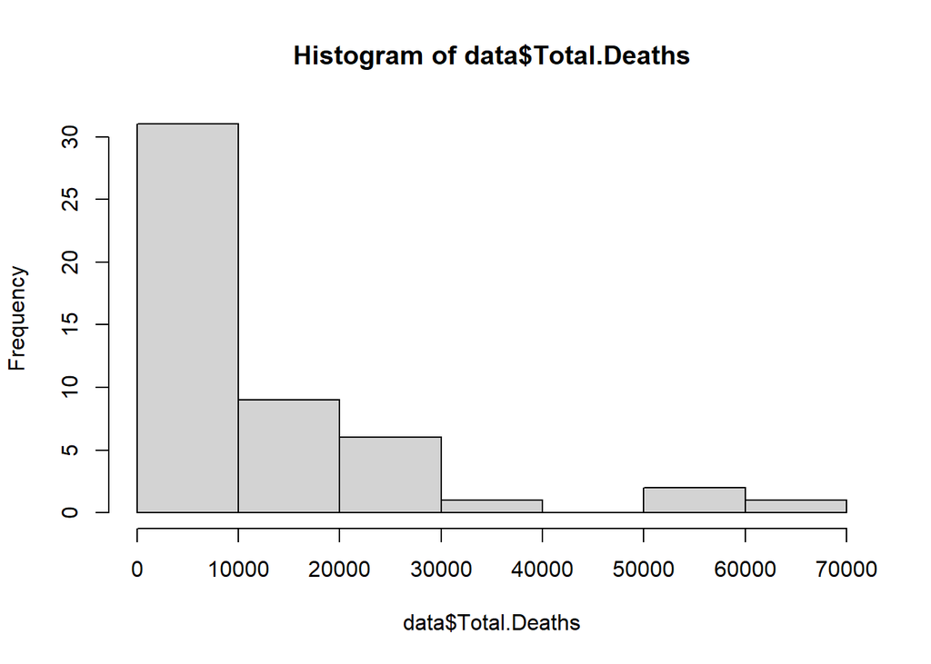

```r
hist(data$Total.Deaths)
```

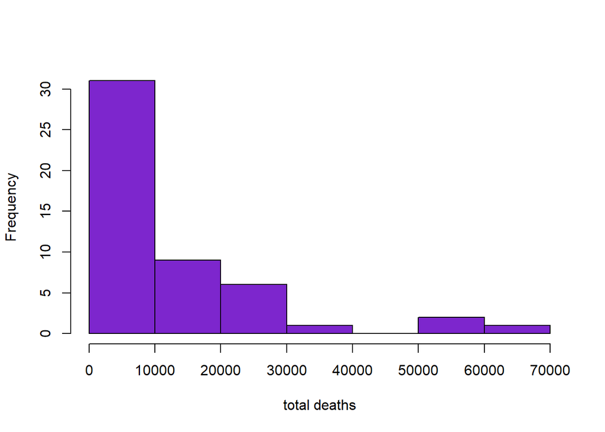

```r
hist(data$Total.Deaths,col='purple3',main=NULL,xlab='total deaths')
```

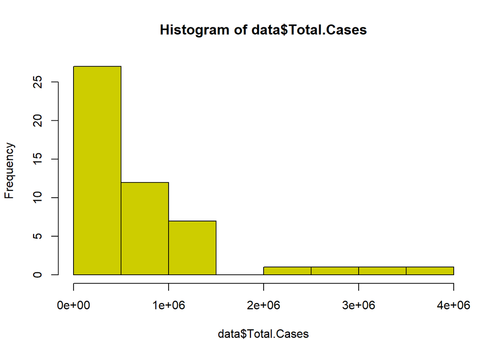

```r
hist(data$Total.Cases,col='yellow3')
```

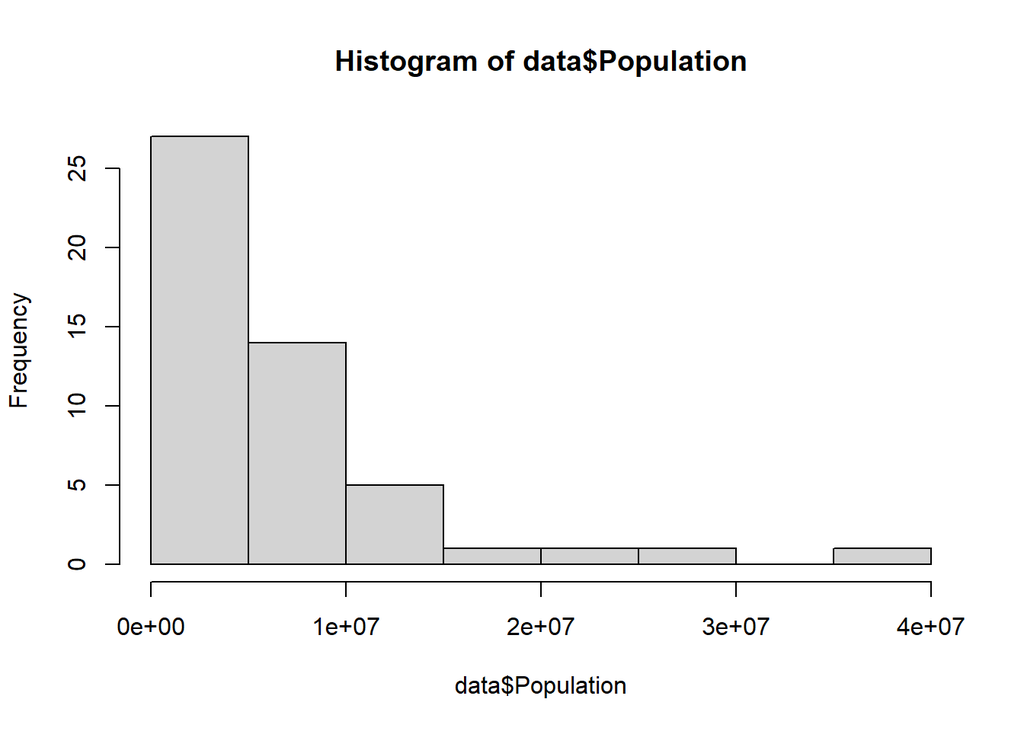

```r
hist(data$Population)
```

Density function: Instead of using frequency=FALSE in the hist() command we can directly use density() command.

```r
density(data$Total.Cases)
```

```
##
## Call:
##  density.default(x = data$Total.Cases)
##
## Data: data$Total.Cases (50 obs.);    Bandwidth 'bw' = 2.042e+05
##
##        x                 y
##  Min.   :-587671   Min.   :4.401e-10
##  1st Qu.: 708347   1st Qu.:2.351e-08
##  Median :2004365   Median :4.090e-08
##  Mean   :2004365   Mean   :1.927e-07
##  3rd Qu.:3300383   3rd Qu.:2.885e-07
##  Max.   :4596401   Max.   :8.869e-07
```

Using density function to Draw a graph:

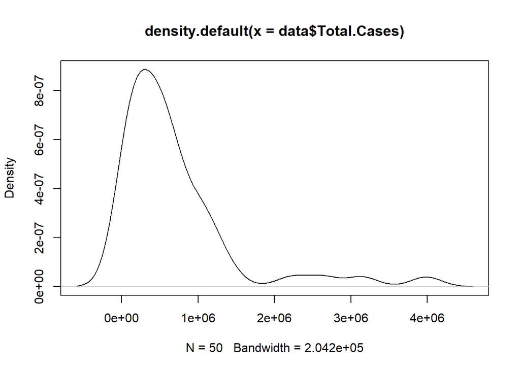

```r
plot(density(data$Total.Cases))
```

Adding density lines to the Existing graphs:

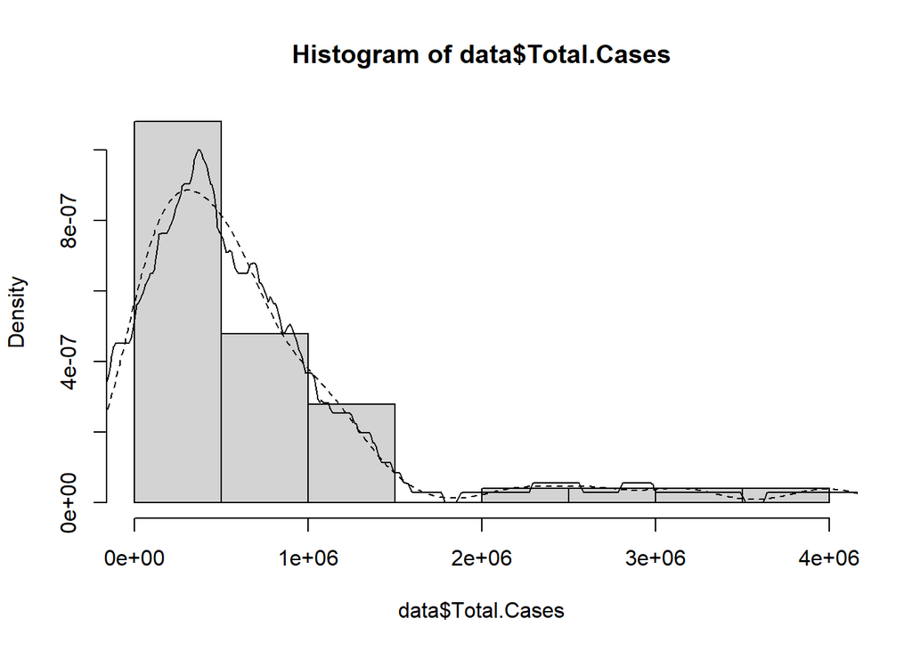

```r
hist(data$Total.Cases, freq = F)
lines(density(data$Total.Cases), lty = 2)
lines(density(data$Total.Cases, k = 'rectangular'))
```

Commands you can use in relation to the normal distribution:

```r
#to generate n random numbers from the normal distribution with mean of 0 and standard deviation of 1.

head(rnorm(data$Total.Cases, mean = 0, sd = 1))
```

```
## [1] -0.83735959  0.15391579  0.35842567 -0.06437277 -0.10736585  1.26989633
```

```r
# for Returning the probability for the quantile q.
head(pnorm(data$Total.Cases, mean = 0, sd = 1))
```

```
## [1] 1 1 1 1 1 1
```

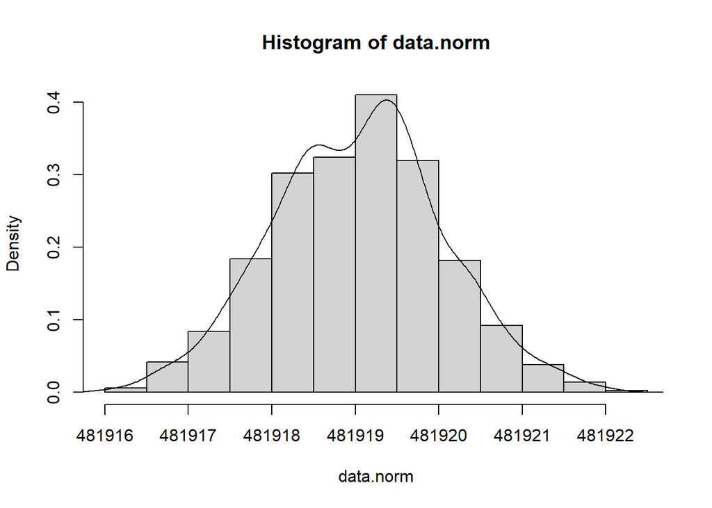

```r
data.norm=rnorm(1000,mean(data$Total.Cases,sd(data$Total.Cases)))
hist(data.norm, freq = FALSE)
lines(density(data.norm))
```

Quantile-Quantile Plot: It produces a series of points that appers in a straight line for normal distribution.

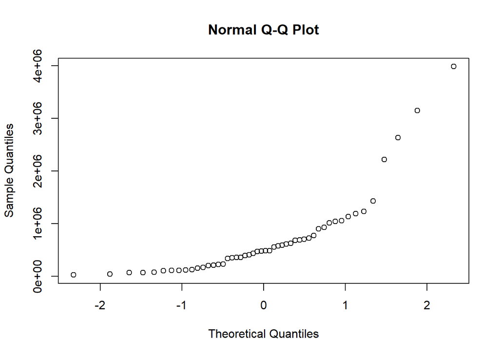

```r
qqnorm(data$Total.Cases)# for non-normal distribution
```

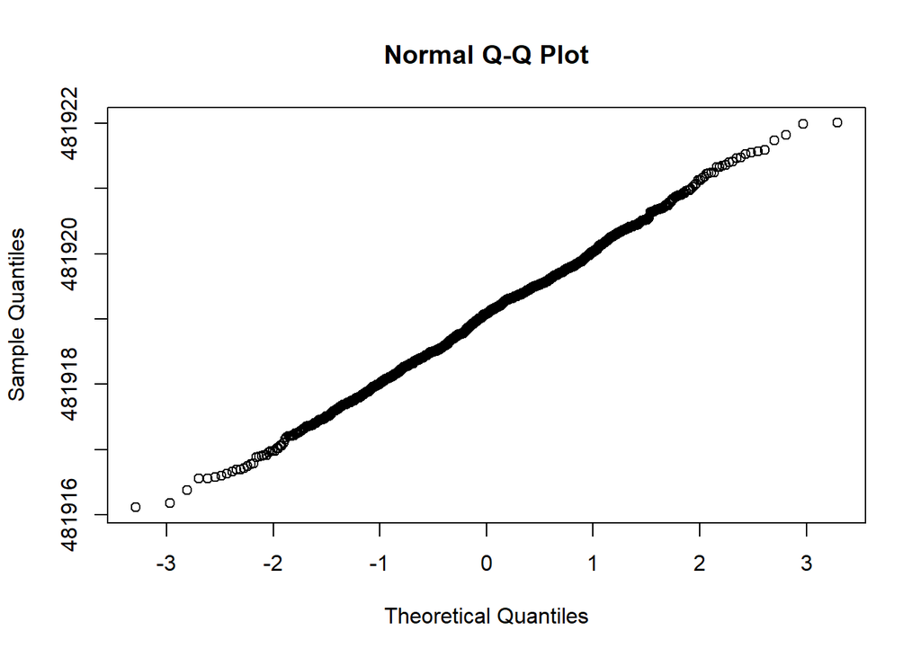

```r
qqnorm(data.norm)# for normal distribution
```

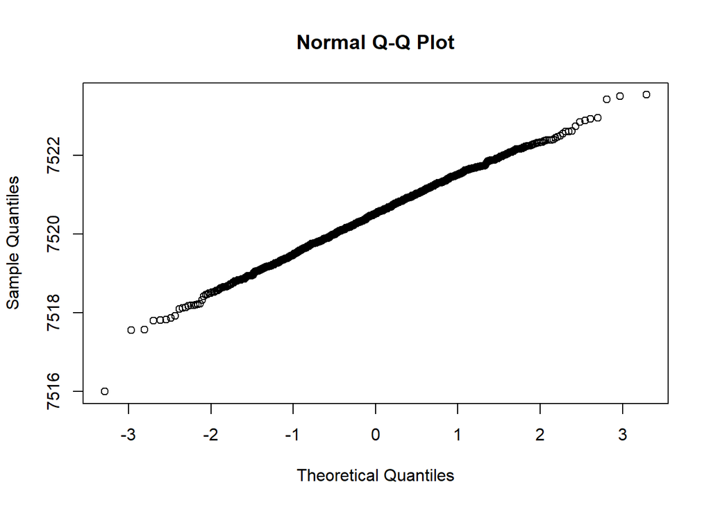

```r
data.norm2=rnorm(1000,mean(data$Total.Deaths,sd(data$Total.Deaths)))
qqnorm(data.norm2)
```

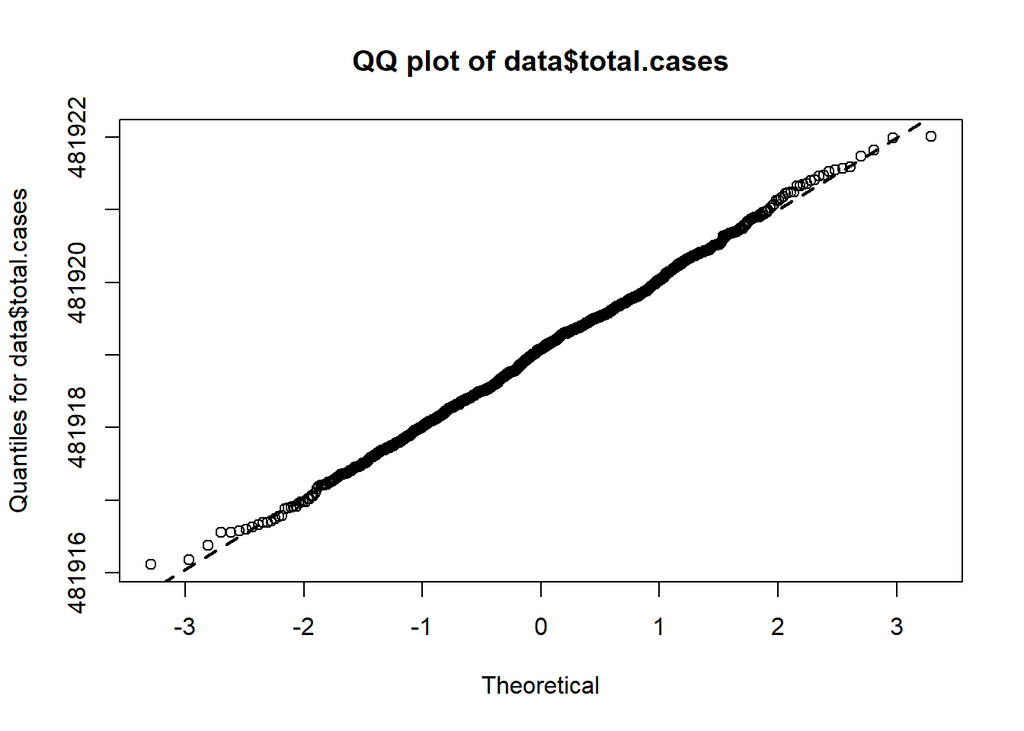

```r
qqnorm(data.norm, main = 'QQ plot of data$total.cases', xlab = 'Theoretical',
ylab = 'Quantiles for data$total.cases')
qqline(data.norm, lwd = 2, lty = 2)
```

It is possible to plot one distribution against another as a quantile-quantile plot using the qqplot() command.

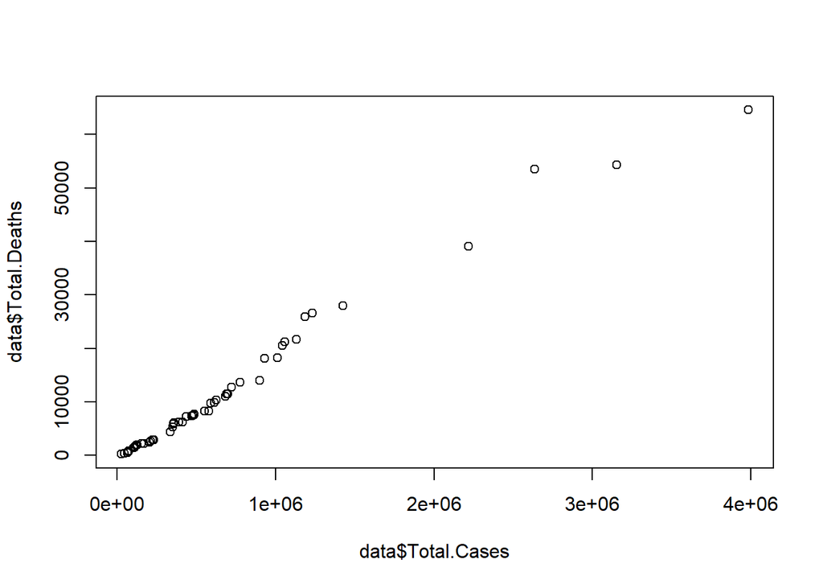

```r
qqplot(data$Total.Cases, data$Total.Deaths)
```

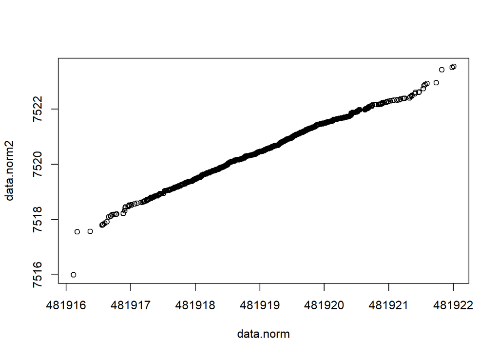

```r
qqplot(data.norm, data.norm2)
```

Drawing a straight line on the qqplot() can be done using the abline() command. This command uses the properties of a straight line (that is, y = a + bx) to produce a line on an existing plot. The general form of the command is: abline(a = intercept, b = slope).

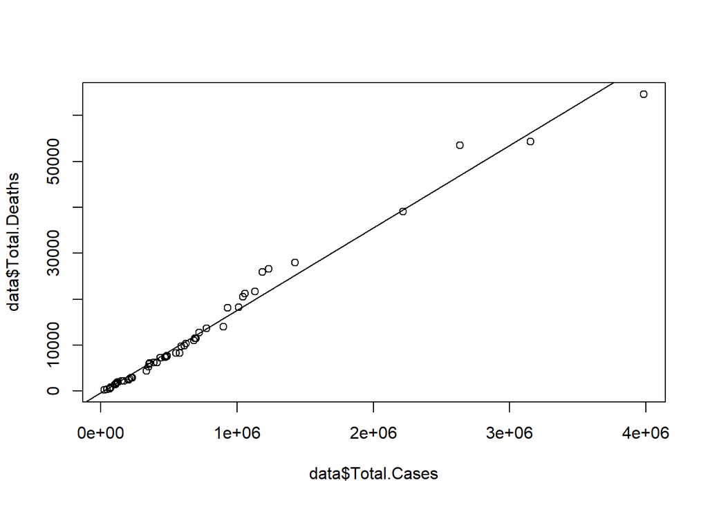

```r
qqp = qqplot(data$Total.Cases, data$Total.Deaths)
abline(lm(qqp$y ~ qqp$x))
```

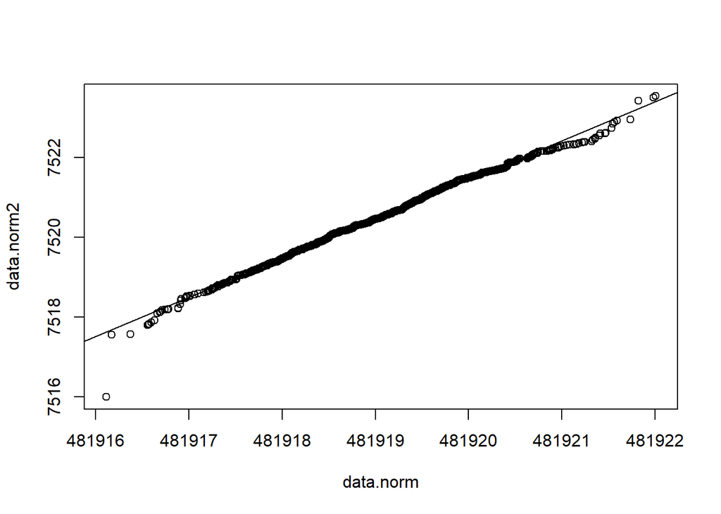

```r
#for normalized data
qqp = qqplot(data.norm, data.norm2)
abline(lm(qqp$y ~ qqp$x))
```

The basic method of applying a t-test is to compare two vectors of numeric data

```r
t.test(data$Total.Cases, data$Total.Deaths)
```

```
##
##  Welch Two Sample t-test
##
## data:  data$Total.Cases and data$Total.Deaths
## t = 6.1311, df = 49.032, p-value = 1.466e-07
## alternative hypothesis: true difference in means is not equal to 0
## 95 percent confidence interval:
##  462468.1 913433.1
## sample estimates:
## mean of x mean of y
## 700174.34  12223.72
```

Two-sample t-Test with unequal variance:

```r
t.test(data$Total.Cases,data$Total.Deaths)
```

```
##
##  Welch Two Sample t-test
##
## data:  data$Total.Cases and data$Total.Deaths
## t = 6.1311, df = 49.032, p-value = 1.466e-07
## alternative hypothesis: true difference in means is not equal to 0
## 95 percent confidence interval:
##  462468.1 913433.1
## sample estimates:
## mean of x mean of y
## 700174.34  12223.72
```

Two-sample t-Test with Equal variances: This can override the default and use the classic t-test by adding the var.equal = TRUE instruction, which forces the command to assume that the variance of the two samples is equal.

```r
t.test(data$Total.Cases, data$Total.Deaths, var.equal = TRUE)
```

```
##
##  Two Sample t-test
##
## data:  data$Total.Cases and data$Total.Deaths
## t = 6.1311, df = 98, p-value = 1.836e-08
## alternative hypothesis: true difference in means is not equal to 0
## 95 percent confidence interval:
##  465281.7 910619.6
## sample estimates:
## mean of x mean of y
## 700174.34  12223.72
```

One sample t-Testing: In this version you supply the name of a single vector and the mean to compare it to (this defaults to 0):

```r
t.test(data$Total.Cases, mu = 5)
```

```
##
##  One Sample t-test
##
## data:  data$Total.Cases
## t = 6.2411, df = 49, p-value = 9.937e-08
## alternative hypothesis: true mean is not equal to 5
## 95 percent confidence interval:
##  474725.0 925623.6
## sample estimates:
## mean of x
##  700174.3
```

Using Directional Hypotheses: In this the direction of the hypotheses can be specified.

```r
t.test(data$Total.Cases, mu = 5, alternative = 'greater')
```

```
##
##  One Sample t-test
##
## data:  data$Total.Cases
## t = 6.2411, df = 49, p-value = 4.969e-08
## alternative hypothesis: true mean is greater than 5
## 95 percent confidence interval:
##  512086.2      Inf
## sample estimates:
## mean of x
##  700174.3
```

Two-Sample U-Test:

```r
wilcox.test(data$Total.Cases, data$Total.Deaths)
```

```
##
##  Wilcoxon rank sum test with continuity correction
##
## data:  data$Total.Cases and data$Total.Deaths
## W = 2490, p-value < 2.2e-16
## alternative hypothesis: true location shift is not equal to 0
```

One-Sample U-Test:

```r
wilcox.test(data$Total.Cases,exact=FALSE)
```

```
##
##  Wilcoxon signed rank test with continuity correction
##
## data:  data$Total.Cases
## V = 1275, p-value = 7.79e-10
## alternative hypothesis: true location is not equal to 0
```

Correlation and Covariance: The cor() command determines correlation and cov()command determines covariance.

```r
#correlation
cor(data$Total.Cases, data$Total.Deaths)
```

```
## [1] 0.9698435
```

```r
#Determines covariance between x and y . If x is a matrix or data frame, y can be omitted.
x=cov(data$Total.Cases, data$Total.Deaths)
x
```

```
## [1] 11045062615
```

The cov2cor() command is used to determine the correlation from a matrix of covariance in the following example:

```r
v = as.matrix(x)
cov2cor(v)
```

```
##      [,1]
## [1,]    1
```

Significance Testing in Correlation Tests:

```r
cor.test(data$Total.Cases, data$Total.Deaths)
```

```
##
##  Pearson's product-moment correlation
##
## data:  data$Total.Cases and data$Total.Deaths
## t = 27.569, df = 48, p-value < 2.2e-16
## alternative hypothesis: true correlation is not equal to 0
## 95 percent confidence interval:
##  0.9471944 0.9828635
## sample estimates:
##       cor
## 0.9698435
```

Chi-squared tests of association can be carried out using the chisq.test() command.

```r
chisq.test(data$Total.Cases)
```

```
##
##  Chi-squared test for given probabilities
##
## data:  data$Total.Cases
## X-squared = 44040184, df = 49, p-value < 2.2e-16
```

BoxPlot’s:

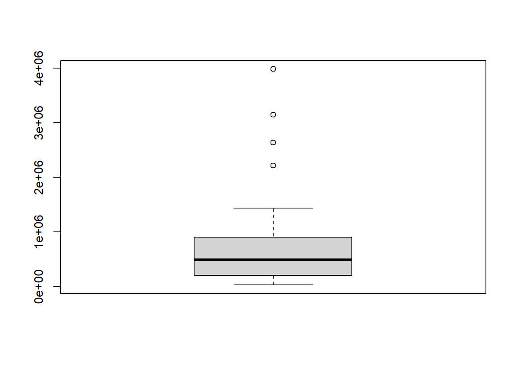

```r
boxplot(data$Total.Cases)
```

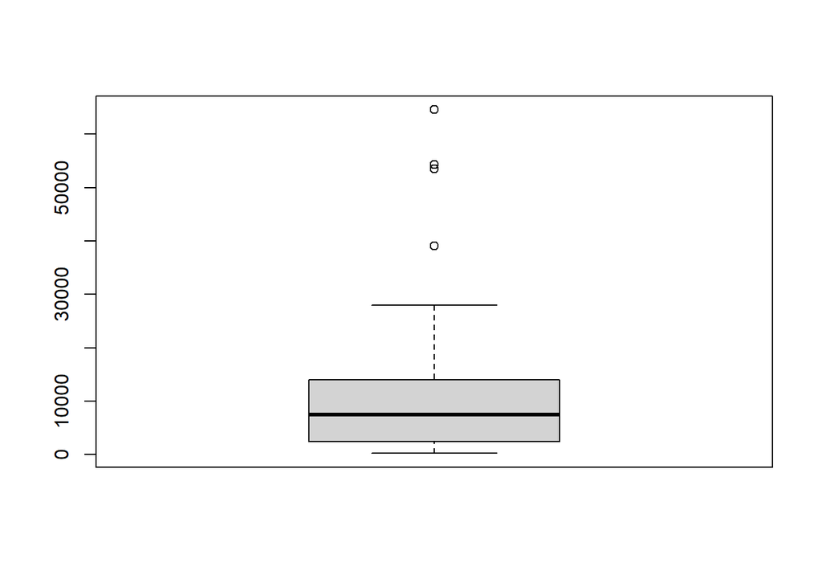

```r
boxplot(data$Total.Deaths)
```

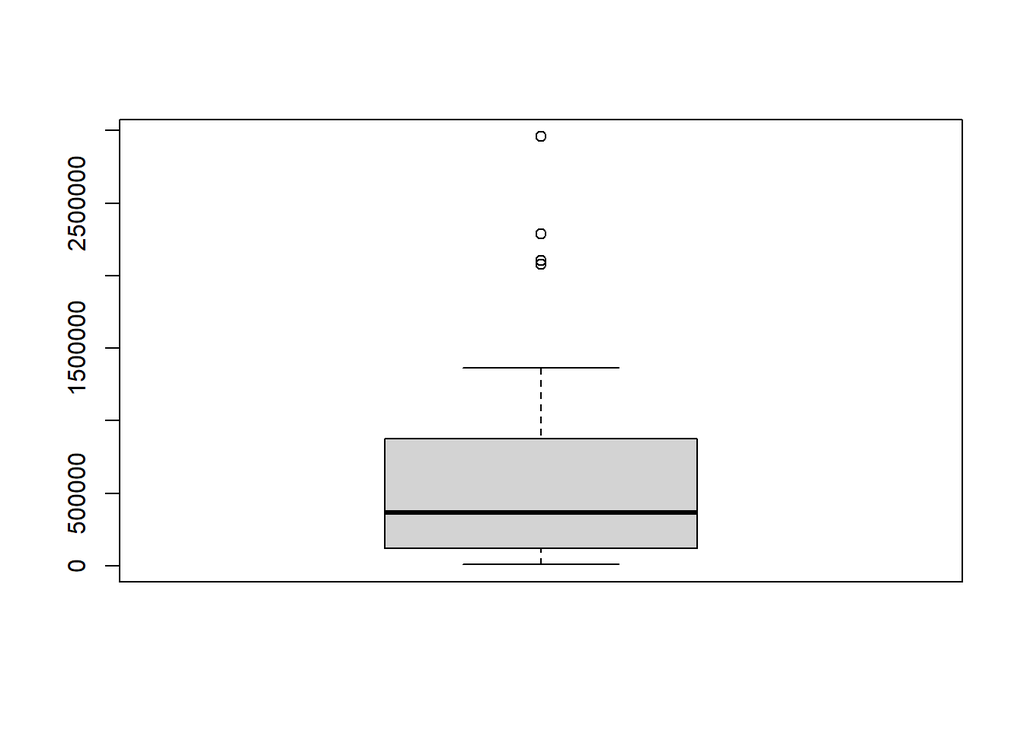

```r
boxplot(data$Total.Recovered)
```

Boxplot for multiple items:

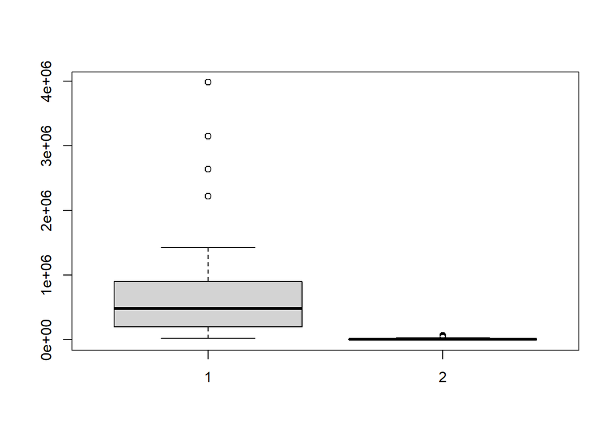

```r
boxplot(data$Total.Cases, data$Total.Deaths)
```

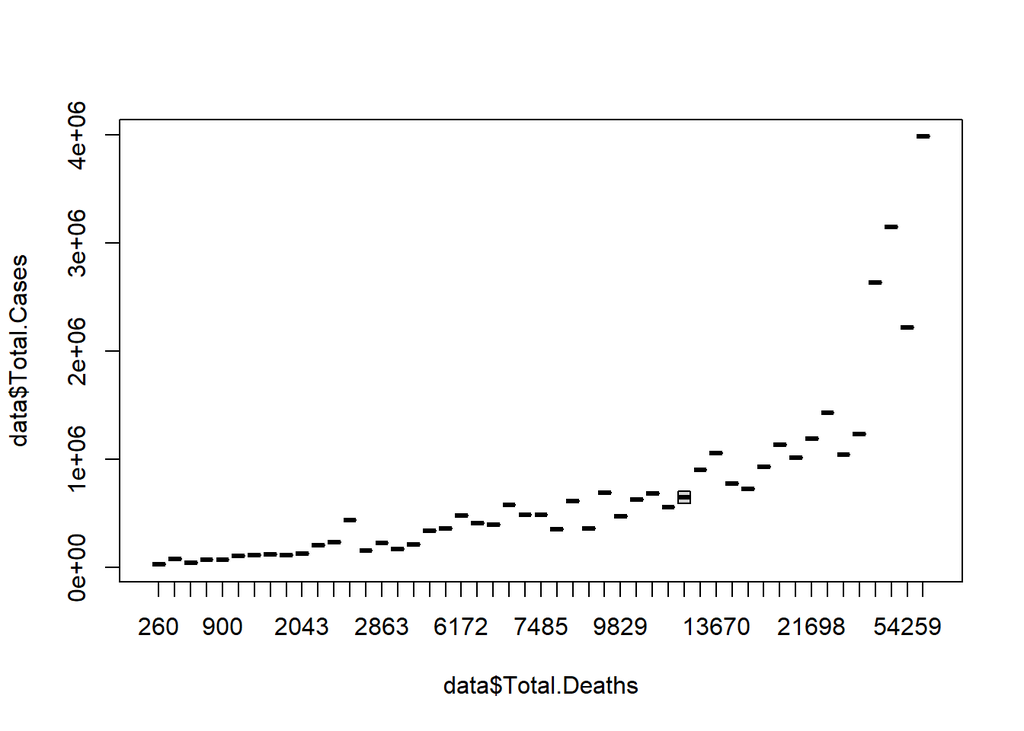

```r
boxplot(data$Total.Cases~data$Total.Deaths , data = data)
```

Customising Boxplots:

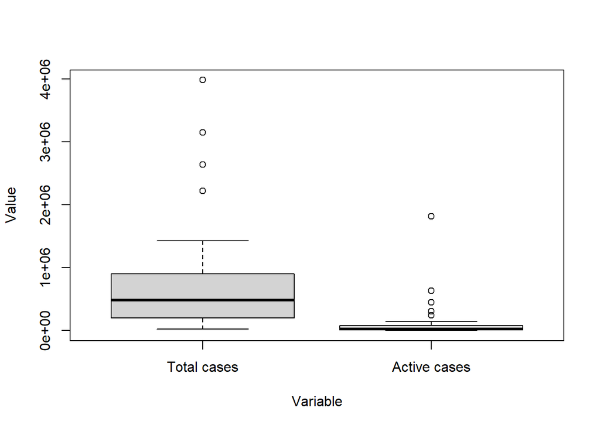

```r
boxplot(data$Total.Cases,data$Active.Cases,names=c('Total cases','Active cases'))
title(xlab="Variable",y="Value")
```

Horizontal Boxplots:

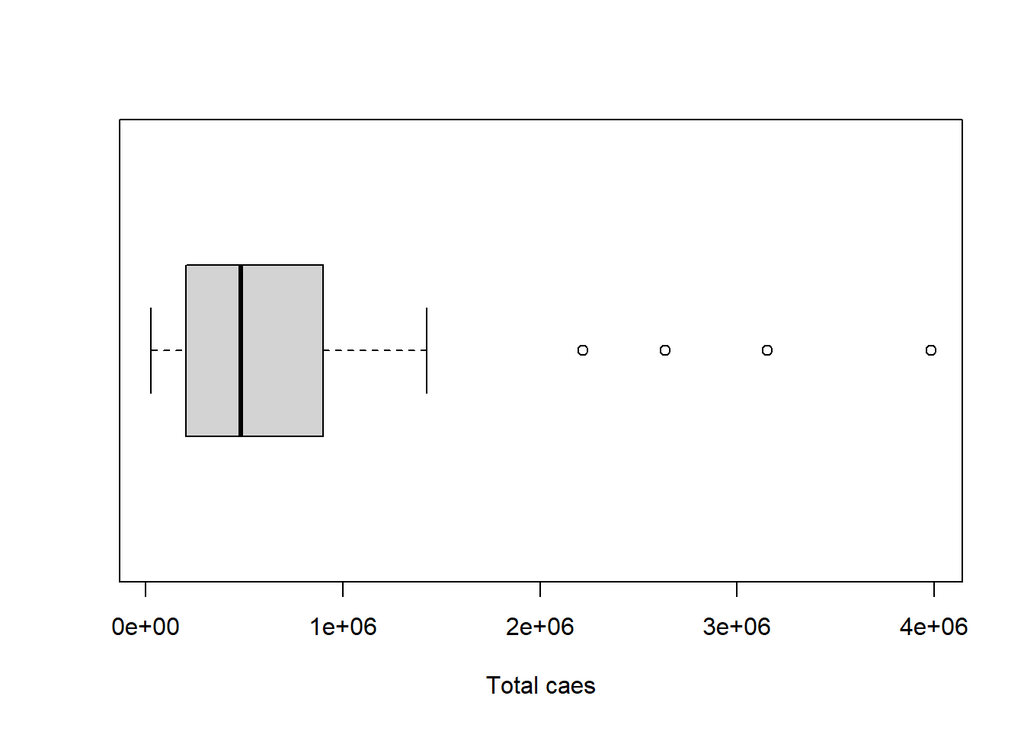

```r
boxplot(data$Total.Cases, horizontal = T)
title(xlab = 'Total caes')
```

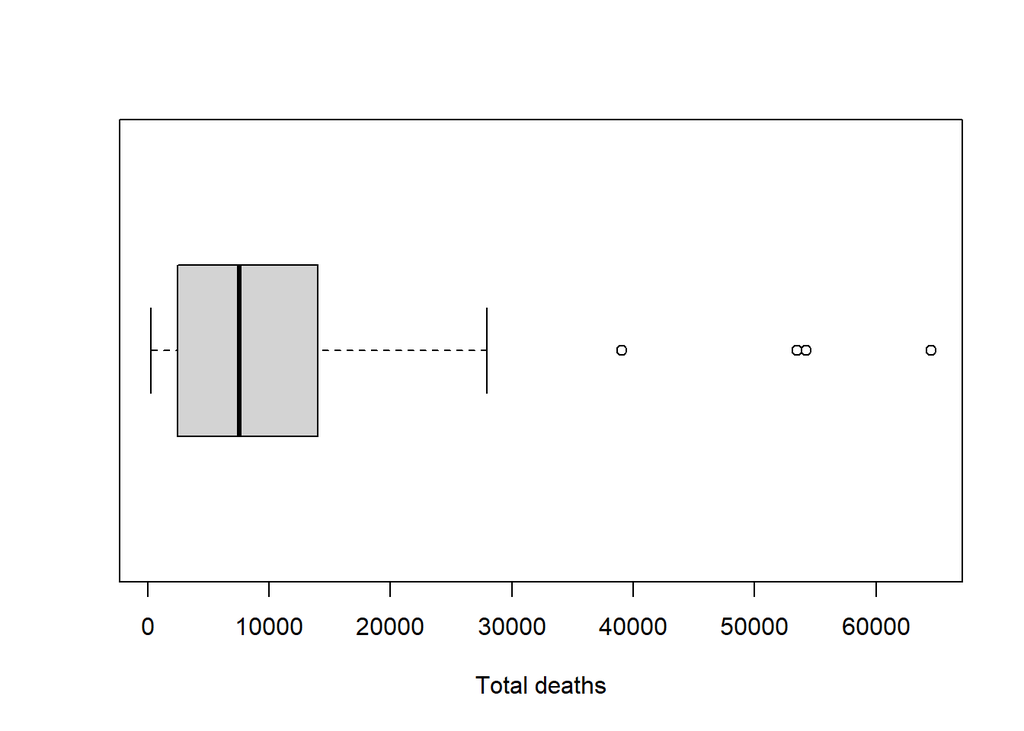

```r
boxplot(data$Total.Deaths, horizontal = T)
title(xlab = 'Total deaths')
```

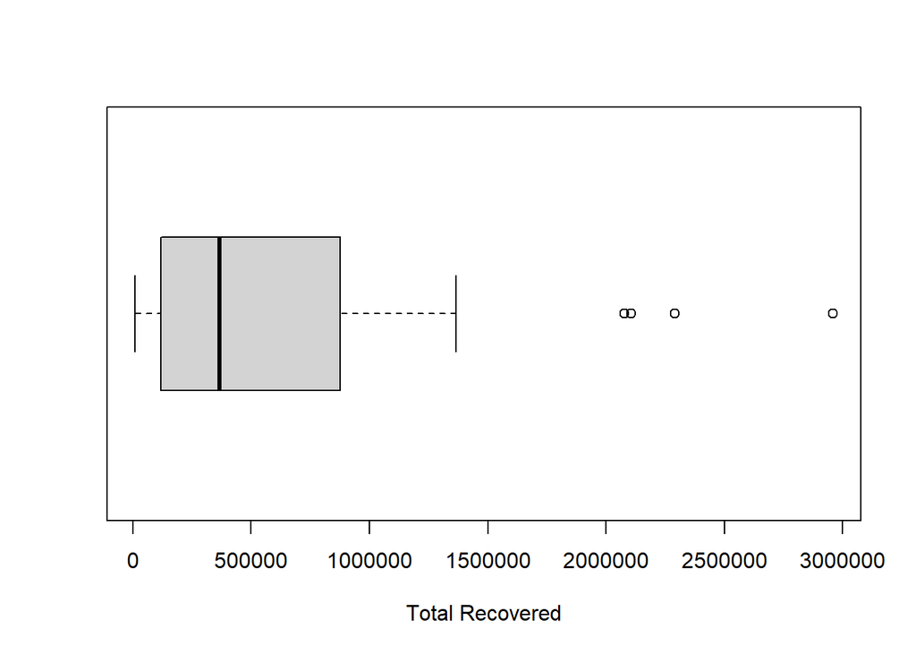

```r
boxplot(data$Total.Recovered, horizontal = T)
title(xlab = 'Total Recovered')
```

scatter plot’s:

```r
library(dplyr)
```

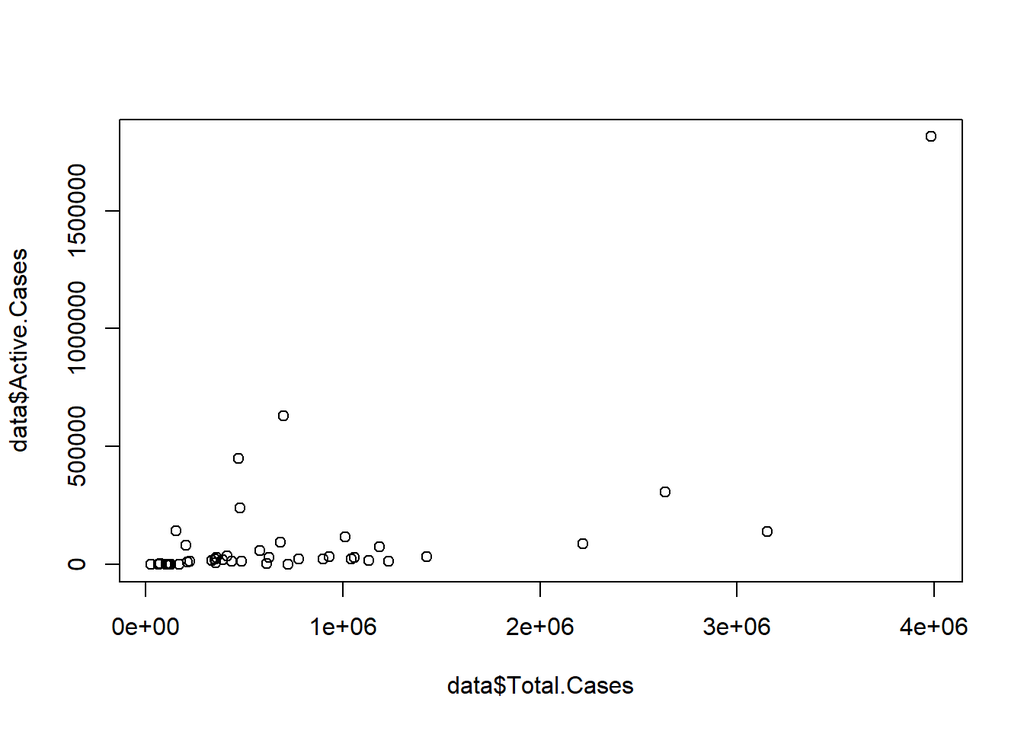

```r
plot(data$Total.Cases,data$Active.Cases)
```

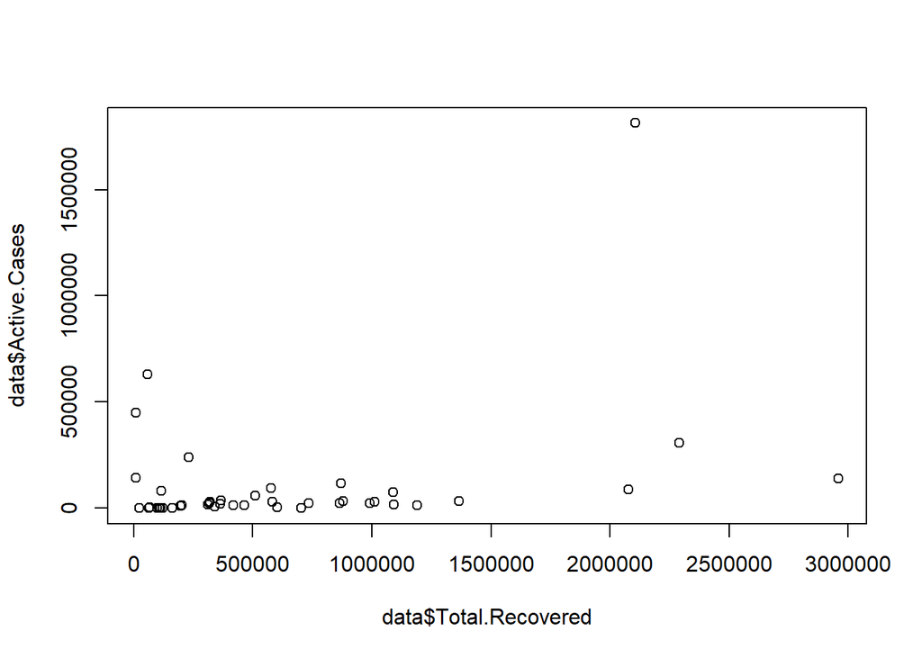

```r
plot(data$Total.Recovered,data$Active.Cases)
```

Pairs plots(multiple correlation plots)

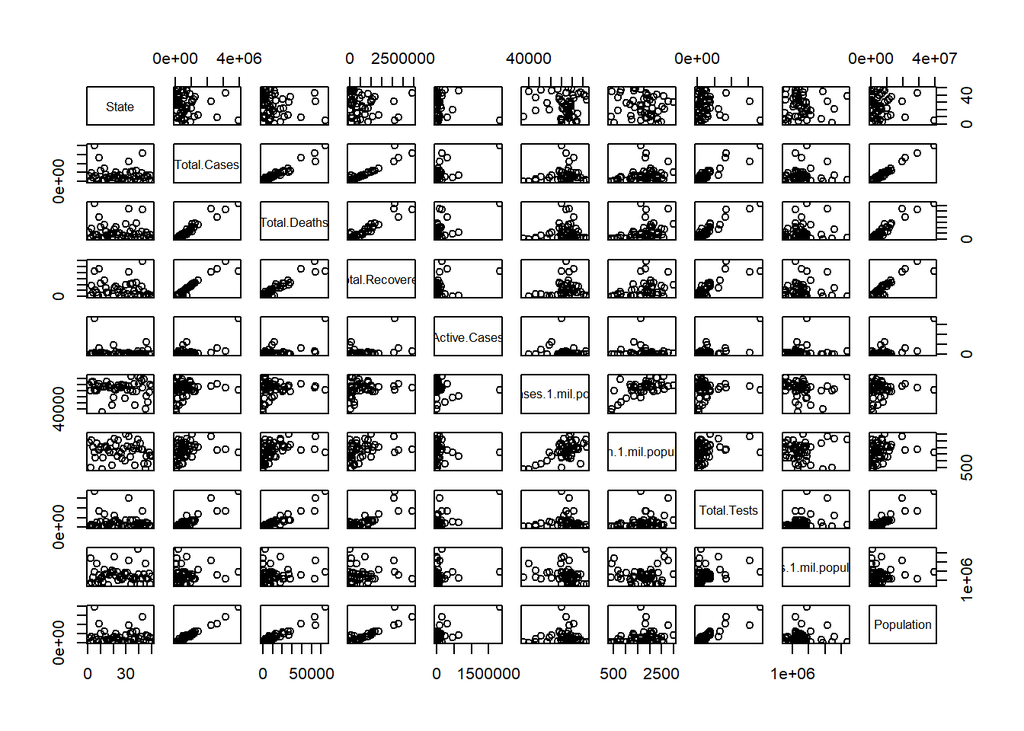

```r
plot(data)
```

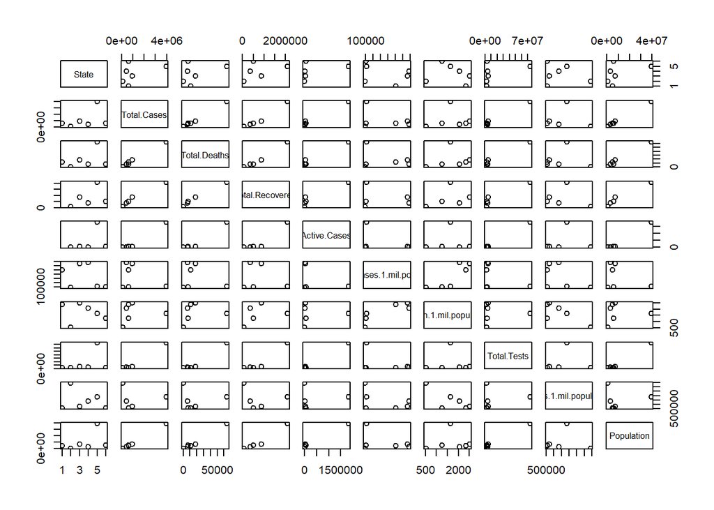

```r
a=head(data)
plot(a)
```

Desired columns can be selected for ploating:

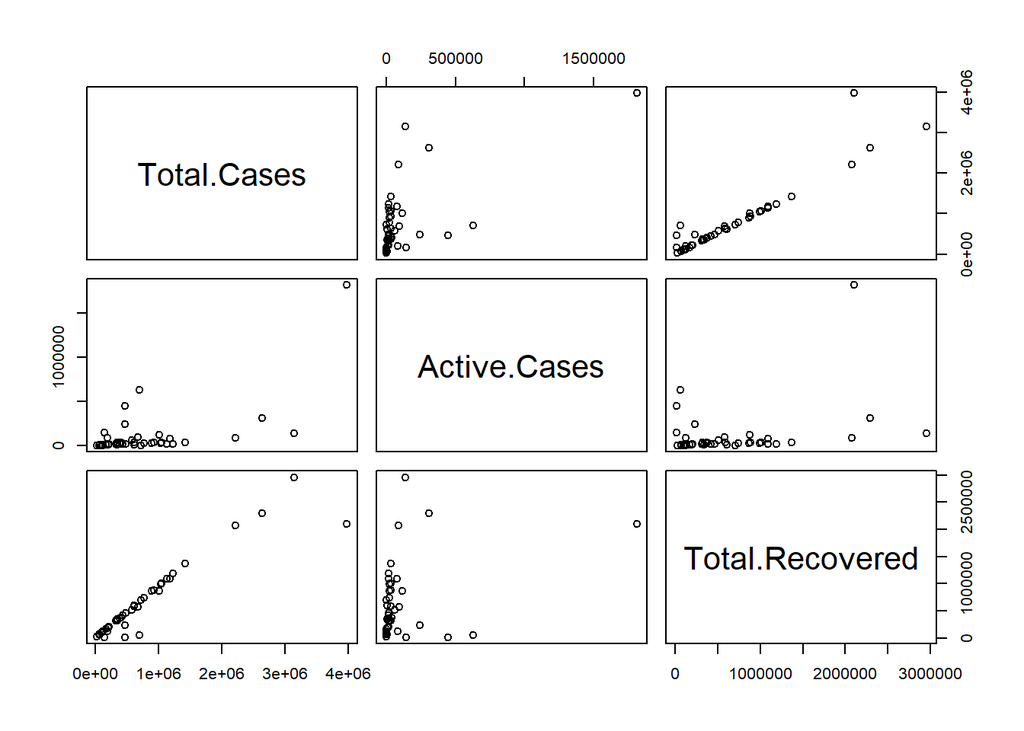

```r
 pairs(~ Total.Cases + Active.Cases + Total.Recovered, data =data)
```

Line Charts:

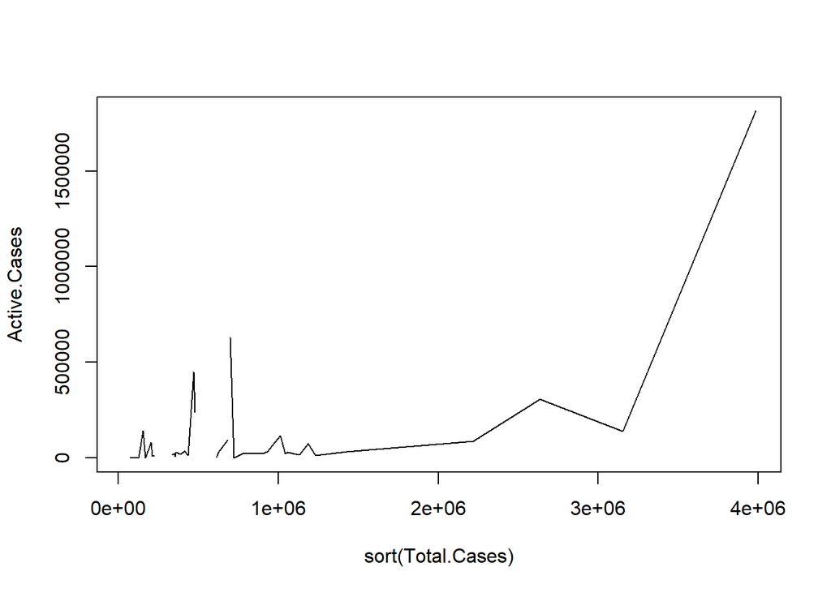

```r
 with(data[order(data$Total.Cases),], plot(sort(Total.Cases), Active.Cases, type = 'l'))
```

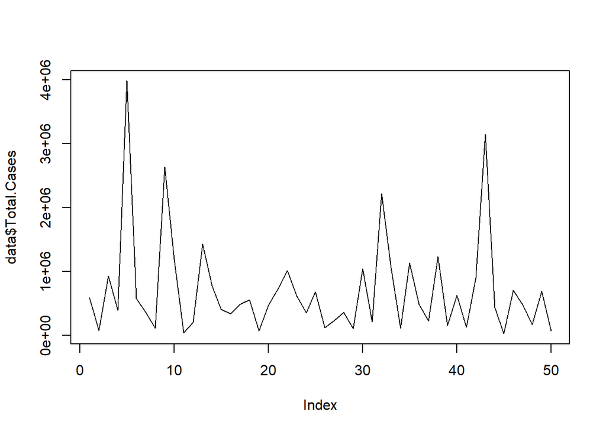

```r
plot(data$Total.Cases, type = 'l' )
```